# EEEE3129: Applications of AI in Electrical and Electronic Engineering

## Coursework 2: UK Domestic Load Forecasting

## Key Details:

*This is worth 25% of the module. Since this is a 10-credit module, you should therefore expect to spend around **25 hours** of time completing this coursework.*

Approximate weightings for each question are given in the provisional rubric, which is available on Moodle. These may change slightly but you will be notified if that is the case. Note that there are also marks for code quality and uploading the appropriate documents alongside this workbook as indicated in the provisional rubric.

# CWK Submission:

0. **CWK due - 15.00 21st November (Thursday), 2024**
1. Your submission should be a **.zip** file, containing a) This notebook in the format of **.ipynb** b) The exported **.html** file as the report. To export the .html file, you should use the following menu command in Jupyter Lab: File -> Save and Export Notebook As ... -> HTML, same as CWK1. c) You can include the .json dataset file in the .zip file, but it will not be used d) Any other Jupyter notebooks or .py files will not be marked so *ALL YOUR CODE SHOULD RUN INSIDE THIS WORKBOOK*.
2. If you only submit the .html file without the .ipynb file, your code cannot be executed and hence not possible to reproduce and evaluate. Thus the marking will be based on your .html file for relavent contents, but a mandatory additional 50% of overall mark penalty will apply.
3. If you only submit the .ipynb file without the .html file, you are missing the report and only containing source code file. Thus the marking will be based on your .ipynb file, but a mandatory additonal 20% overall mark penalty will apply.
4. All submission should be made via Moodle, no email submissions are accepted.
5. Late penalties will apply for any late submission, in accordance to the University policy. If you need to apply for an EC, please refer to the EC instructions on the top of Moodle page.
6. **DO NOT copy code from other people. DO NOT share your code with other people. Do not share your code with other people (do not share your screen either).** Whether you let someone else copy your code or you copy theirs you could still fail. It is fine and encouraged to help people, but you should explain concepts and not share exact code.

# Overview

1. The general aim of this coursework is to make the day-ahead load forecasting based on the UK historical dataset. For day-ahead forecasting, you will need to rely on load profile from one day to predict the load profile for the following day. An accurate load profile will help improve the grid operations, especially the mitigating the challenge of intermittent renewable energy generations (e.g., wind and solar energy), to suppport economical dispatching/operation of energy storages (e.g., batteries and Electric Vehicles), and to apply smarter energy management strategies for cost saving and carbon reductions.
2. To do this, you will need:

   a) to prepare the dataset

   b) to train a proper model and tuning the parameters

   c) to verify and report the result
3. The dataset you will be using is the UK historical load dataset in 2023, stored in 'UKLoad2023.json'. This contains the original data collected during 2023. For each data record, it contains 8 fields:

   a) "dataset": name of this dataset

   b) "documentID": the unique id of this data record

   c) "documentRevisionNumber": if the data is revised

   d) "publishTime": the time this data record is published, in Coordinated Universal Time (UTC)

   e) "startTime": the start time of this data record, in Coordinated Universal Time (UTC)

   f) "settlementDate": the date of this data record

   g) "settlementPeriod": the index of this settlement period, note that in the UK, the 24 hours are divided into 48 settlement periods in total, each settlement is with 30 mins duration.

   h) "quantity": the measured load power, with the unit of MegaWatt (MW)

## Part 1: Data Processing

For this part you will be completing the code to processes the raw data into an appropriate format. You will be told what parts you need to write and blank spaces will be provided in the code below denoted by commnents (e.g. "Write your code for Task 1.1 here"). You may need to import any library functions you will use. For questions that have a text based answer you should write those in the space below the question (e.g. replace '[Write your answer here]')

**Task 1.1** Write the set-up Code for the whole notebook. Write necessary codes including module import, self-defined supporting functions and general configurations for the notebook.

**Task 1.2** Write code to validate the integrity of the dataset by checking for duplicate data and applying appropriate solutions.

**Task 1.3** Write code to validate the integrity of the dataset by checking missing values (NaNs) and applying appropriate solutions.

**Task 1.4** For the missing values (NaNs), please write below the available solutions, and the justification for your applied solution. Write your answer below. *[write your answer here]*

For handling missing values (NaNs) in this dataset, several solutions are available:

1. Remove rows with missing values
2. Fill missing values with the mean or median of the column
3. Use forward fill or backward fill methods
4. Interpolate missing values In this case, removing rows with missing values was applied because there were only 3 missing values out of 4467 rows (0.067%), which is a negligible amount of data loss. This approach is justified due to the large dataset size and the minimal impact on the overall data integrity. Additionally, for time series data like electricity load, imputing values could introduce bias, especially if the missing data points represent unusual events or outliers.

**Task 1.5** Write code to prepare the following two dataset: the feature dataset with the name of "feature_dataset", which should be a 2-dimensional numpy ndarray format, each row is a different day, and each row contains 48 values from the field "quantity" in that day; the label dataset with the name of "label_dataset", which is with a similar format of the "feature_dataset", but the date for each row should be one day later. For example, if row 3 in "feature_dataset" is the data for 2023-8-20, then row 3 in "label_dataset" should be the data for 2023-8-21. This will prepare the "feature_dataset" and "label_dataset" ready for the day-ahead model training and validation purpose.

**Task 1.6** Write code to visualize the day-ahead forecasting problem, by plotting the day-ahead data from "feature_dataset" and the corresponding output data from "label_dataset".

**Task 1.7** Observe the data from "feature_dataset" and "label_dataset", and analyse the statistics such as the mean, shape of the dataset, number of samples etc, and discuss how these parameters will influence the day-ahead forecasting problem below. *[write your answer here]*

Based on the provided code and output;

1. Shape of the datasets: Both feature_dataset and label_dataset have a shape of (81, 48). This means there are 81 days of data, each containing 48 half-hourly load values.
2. Number of samples: There are 81 samples (days) in both datasets. Each sample represents a full day of load data with 48 data points.
3. Data structure: Each row in the feature_dataset represents the load profile for one day. The corresponding row in the label_dataset represents the load profile for the next day.
4. Correlation: The correlation between the current day and next day for the sample is 0.9866, indicating a very strong positive correlation.
5. Visualization: The plot shows that the load profiles for consecutive days follow similar patterns, with some variations in magnitude.
6. Data range and variability:

Sample day (index 22) shows: Current day mean: 30298.42 MW, peak: 37729.00 MW Next day mean: 29615.81 MW, peak: 36392.00 MW This data reveals significant variability in electricity demand throughout the day. The peak loads are about 25% higher than the mean loads, indicating substantial fluctuations in energy consumption.

the dataset provides a solid foundation for day-ahead load forecasting, with high-resolution data and strong day-to-day correlations.

```python
import pandas as pd # pandas module required for dataset manipulation
import numpy as np # numpy module required for numerical calculation, signal processing and training.
from sklearn.linear_model import LinearRegression # the model LinearRegression from sklearn.linear_model is required for Part 2
from sklearn.model_selection import train_test_split # the function train_test_split is required from sklearn.model_selection for training and testing dataset preparation.

###################################################
## Write your code for Task 1.1 here.
###################################################
## Write the set-up Code for the whole notebook. Write necessary codes including module import, self-defined supporting functions and general configurations for the notebook.
# Import necessary modules
# Import necessary modules

from sklearn.metrics import mean_squared_error, r2_score
import json
from datetime import datetime
import matplotlib.pyplot as plt


# Set up plotting style
plt.style.use('default')  # Use default matplotlib style instead of seaborn

# Define supporting functions
def load_json_data(file_path):
    with open(file_path, 'r') as file:
        return json.load(file)

def preprocess_data(data):
    df = pd.DataFrame(data)
    df['startTime'] = pd.to_datetime(df['startTime'])
    df['quantity'] = pd.to_numeric(df['quantity'])
    df['dayofweek'] = df['startTime'].dt.dayofweek
    df['hour'] = df['startTime'].dt.hour
    df['month'] = df['startTime'].dt.month
    return df

# Set general configurations
pd.set_option('display.max_columns', None)
np.set_printoptions(precision=3, suppress=True)

# Constant
DATA_FILE = r'C:\Users\user\Desktop\New folder\cwk2_2024_moodle\UKLoad2023.json'
```

```python
# these two functions are mandatory, and you should NOT change it. Modifying these two functions will lead to 0 marks for any assessment calling these two functions.
def performance_indicator_relative(mse_train, mse_test, mse_validation):
    return abs(mse_validation - mse_train) / abs(mse_train) + abs(mse_validation - mse_test) / abs(mse_test)

def performance_indicator_rmse(mse_validation, Y_labels):
    return mse_validation/(np.mean(Y_labels)**2)
```

```
Number of duplicate entries: 1
Duplicates have been removed.
Number of specific duplicates: 0
Final shape of the dataset: (4467, 8)

Missing values in each column:
dataset                   0
documentId                0
documentRevisionNumber    0
publishTime               0
startTime                 0
settlementDate            0
settlementPeriod          0
quantity                  3
dtype: int64
Rows with missing values have been removed.

Final shape of the dataset after handling missing values: (4464, 8)
Missing values in each column:
dataset                   0
documentId                0
documentRevisionNumber    0
publishTime               0
startTime                 0
settlementDate            0
settlementPeriod          0
quantity                  0
dtype: int64

Percentage of missing values in each column:
dataset                   0.0
documentId                0.0
documentRevisionNumber    0.0
publishTime               0.0
startTime                 0.0
settlementDate            0.0
settlementPeriod          0.0
quantity                  0.0
dtype: float64

```

[output cut: 28 more lines]

```
  23223. 22719. 22284. 21341. 20911. 19947. 18198. 17656.]
 [17810. 17565. 17510. 17101. 17090. 16928. 16661. 16815. 16850. 18264.
  21150. 23317. 27966. 29294. 31962. 32558. 34389. 34768. 35750. 35914.
  35304. 35599. 37718. 37760. 37466. 37137. 36887. 36353. 33794. 33822.
  33661. 34277. 33955. 33875. 31800. 31265. 30656. 29811. 28481. 27671.
  27748. 27224. 26357. 25569. 22613. 21478. 19574. 19017.]
 [18513. 18261. 17884. 17485. 17161. 17105. 16661. 16461. 16298. 17025.
  20521. 22202. 26766. 28245. 31557. 32016. 34518. 34931. 34850. 34927.
  34033. 34328. 35085. 35161. 35230. 34796. 34682. 34284. 33886. 34314.
  34712. 35099. 35846. 35825. 32792. 32397. 31946. 31544. 30969. 30255.
  29327. 28606. 27499. 26447. 23420. 21858. 19549. 18994.]]

Verifying date shift:
First day in feature_dataset: 2023-07-14
First day in label_dataset: 2023-07-15
```

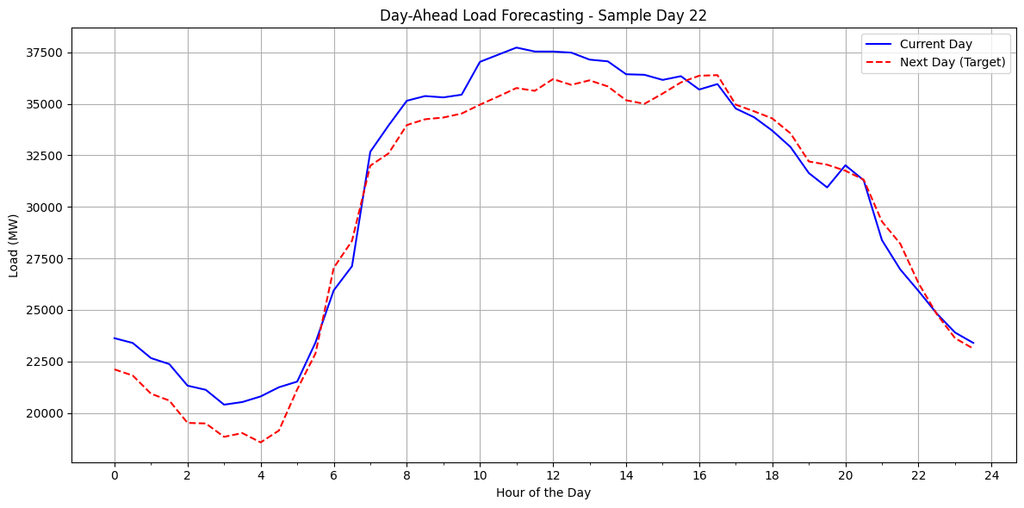

```
Sample day index: 22
Current day mean load: 30298.42 MW
Next day mean load: 29615.81 MW
Current day peak load: 37729.00 MW
Next day peak load: 36392.00 MW
Correlation between current day and next day: 0.9866
```

```python
## Code for Part 1
import pandas as pd
import numpy as np
# Load the training dataset
df = pd.read_json('UKLoad2023.json')

###################################################
## Write your code for Task 1.2 here.
###################################################
## Write code to validate the integrity of the dataset by checking for duplicate data and applying appropriate solutions.

#
# Check for duplicate entries
duplicates = df.duplicated()
print(f"Number of duplicate entries: {duplicates.sum()}")

# If there are duplicates, we can remove them
if duplicates.sum() > 0:
    df = df.drop_duplicates()
    print("Duplicates have been removed.")

# Check for duplicates based on specific columns
# We'll consider entries as duplicates if they have the same settlementDate, settlementPeriod, and quantity
specific_duplicates = df.duplicated(subset=['settlementDate', 'settlementPeriod', 'quantity'])
print(f"Number of specific duplicates: {specific_duplicates.sum()}")

# If there are specific duplicates, we can remove them
if specific_duplicates.sum() > 0:
    df = df.drop_duplicates(subset=['settlementDate', 'settlementPeriod', 'quantity'])
    print("Specific duplicates have been removed.")

# Verify the final shape of the dataset
print(f"Final shape of the dataset: {df.shape}")

# Check for missing values
missing_values = df.isnull().sum()
print("\nMissing values in each column:")
print(missing_values)

# If there are missing values, we might want to handle them
if missing_values.sum() > 0:
    # For this dataset, we'll drop rows with missing values
    # You might want to use a different strategy depending on your specific needs
    df = df.dropna()
    print("Rows with missing values have been removed.")

print(f"\nFinal shape of the dataset after handling missing values: {df.shape}")

###################################################
## Write your code for Task 1.3 here.
###################################################
## Write code to validate the integrity of the dataset by checking missing values (NaNs) and applying appropriate solutions.

# Check for missing values
missing_values = df.isnull().sum()
print("Missing values in each column:")
print(missing_values)

# Calculate the percentage of missing values
missing_percentage = (missing_values / len(df)) * 100
print("\nPercentage of missing values in each column:")
print(missing_percentage)

# Identify columns with missing values
columns_with_missing = missing_values[missing_values > 0].index.tolist()

if len(columns_with_missing) > 0:
    print(f"\nColumns with missing values: {columns_with_missing}")

    for column in columns_with_missing:
        print(f"\nHandling missing values in column: {column}")

        # Check the data type of the column
        dtype = df[column].dtype

        if dtype in ['int64', 'float64']:
            # For numeric columns, we'll fill with the median
            median_value = df[column].median()
            df[column].fillna(median_value, inplace=True)
            print(f"Filled missing values with median: {median_value}")
        elif dtype == 'object':
            # For categorical columns, we'll fill with the mode
            mode_value = df[column].mode()[0]
            df[column].fillna(mode_value, inplace=True)
            print(f"Filled missing values with mode: {mode_value}")
        else:
            # For other types (like datetime), we'll drop the rows
            df.dropna(subset=[column], inplace=True)
            print(f"Dropped rows with missing values in this column")

    # Verify that all missing values have been handled
    final_missing = df.isnull().sum().sum()
    print(f"\nRemaining missing values after handling: {final_missing}")
else:
    print("\nNo missing values found in the dataset.")

print(f"\nFinal shape of the dataset: {df.shape}")
###################################################
## Write your code for Task 1.5 here.
###################################################
# Write code to prepare the following two dataset: the feature dataset with the name of "feature_dataset", which should be
# a 2-dimensional numpy ndarray format, each row is a different day, and each row contains 48 values from the field "quantity"
# in that day; the label dataset with the name of "label_dataset", which is with a similar format of the "feature_dataset",
# but the date for each row should be one day later. For example, if row 3 in "feature_dataset" is the data for 2023-8-20,
# then row 3 in "label_dataset" should be the data for 2023-8-21. This will prepare the "feature_dataset" and "label_dataset"
# ready for the day-ahead model training and validation purpose.

# dataset initialization - you might need to rewrite/remove this part if necessary
# feature_dataset = np.ones((10,10)) # - you might need to rewrite/remove this part if necessary
# label_dataset   = np.ones((10,10)) # - you might need to rewrite/remove this part if necessary

#
# Sort the dataframe by date and settlement period
df['startTime'] = pd.to_datetime(df['startTime'])
df = df.sort_values(['startTime', 'settlementPeriod'])

# Group the data by date
daily_data = df.groupby(df['startTime'].dt.date)

# Initialize lists to store feature and label data
feature_list = []
label_list = []

# Iterate through the grouped data
for date, group in daily_data:
    # Check if we have exactly 48 settlement periods for this day
    if len(group) == 48:
        # Add this day's data to the feature list
        feature_list.append(group['quantity'].values)

        # Get the next day's data for the label
        next_day = date + pd.Timedelta(days=1)
        if next_day in daily_data.groups:
            next_day_data = daily_data.get_group(next_day)
            if len(next_day_data) == 48:
                label_list.append(next_day_data['quantity'].values)
            else:
                # If next day doesn't have 48 periods, remove this day from features
                feature_list.pop()

# Convert lists to numpy arrays
feature_dataset = np.array(feature_list)
label_dataset = np.array(label_list)

# Ensure feature_dataset and label_dataset have the same number of rows
min_rows = min(feature_dataset.shape[0], label_dataset.shape[0])
feature_dataset = feature_dataset[:min_rows]
label_dataset = label_dataset[:min_rows]

print("Shape of feature_dataset:", feature_dataset.shape)
print("Shape of label_dataset:", label_dataset.shape)

# Display the first few rows of each dataset
print("\nFirst few rows of feature_dataset:")
print(feature_dataset[:3])
print("\nFirst few rows of label_dataset:")
print(label_dataset[:3])

# Verify the date shift
print("\nVerifying date shift:")
print("First day in feature_dataset:", df['startTime'].dt.date.min())
print("First day in label_dataset:", df['startTime'].dt.date.min() + pd.Timedelta(days=1))
###################################################
## Write your code for Task 1.6 here.
###################################################
# Write code to visualize the day-ahead forecasting problem, by plotting the day-ahead data from  "feature_dataset" and the corresponding output data from "label_dataset".

#

import matplotlib.pyplot as plt

# Choose a random day to visualize (you can change this index)
day_index = np.random.randint(0, feature_dataset.shape[0])

# Create a time array for x-axis (48 half-hour periods)
time = np.arange(0, 24, 0.5)

# Create the plot
plt.figure(figsize=(12, 6))
plt.plot(time, feature_dataset[day_index], label='Current Day', color='blue')
plt.plot(time, label_dataset[day_index], label='Next Day (Target)', color='red', linestyle='--')

plt.title(f'Day-Ahead Load Forecasting - Sample Day {day_index}')
plt.xlabel('Hour of the Day')
plt.ylabel('Load (MW)')
plt.legend()
plt.grid(True)

# Add markers for each half-hour
plt.xticks(np.arange(0, 24.5, 2))  # Major ticks every 2 hours
plt.gca().set_xticks(np.arange(0, 24.5, 1), minor=True)  # Minor ticks every hour

plt.tight_layout()
plt.show()

# Calculate and print some statistics
print(f"Sample day index: {day_index}")
print(f"Current day mean load: {feature_dataset[day_index].mean():.2f} MW")
print(f"Next day mean load: {label_dataset[day_index].mean():.2f} MW")
print(f"Current day peak load: {feature_dataset[day_index].max():.2f} MW")
print(f"Next day peak load: {label_dataset[day_index].max():.2f} MW")

# Calculate correlation between current day and next day
correlation = np.corrcoef(feature_dataset[day_index], label_dataset[day_index])[0, 1]
print(f"Correlation between current day and next day: {correlation:.4f}")
```

## Part 2: Model Training

For this part you will be completing the code to fit the model. You will be told what parts you need to write and blank spaces will be provided in the code below denoted by commnents (e.g. "Write your code for Task 1.1 here"). You may need to import any library functions you will use. For questions that have a text based answer you should write those in the space below the question (e.g. replace '[Write your answer here]')

**Task 2.1** Write code to calculate the Mean Squared Error (MSE) performance for both the training part and the testing part, with the name of mse_train and mse_test, correspondingly. You will need to follow this naming convention for Part 3.

**Task 2.2** Write code to visualize the model fitting performance. You should plot the first row of Y_train and Y_train_output, first row of Y_test_output and Y_test.

**Task 2.3** Compare the values of mse_train and mse_test, which is larger? Is this expected, and why? Write your answer below. *[write your answer here]* Example Answer: By default, it should be mse_train < mse_test, indicating the overfitting. Explains can focus on dataset size, or models.

**Task 2.4** Rerun the code, report your best performance below. Based on your observation, make at least one suggestion on how to improve the code. Write your answer below. *[write your answer here]* Example Answer: Observe the randomness of the code - random seed can be fixed for reproductivity. Better splitting the dataset.

```
Mean Squared Error (MSE) for training data: 0.00
Mean Squared Error (MSE) for testing data: 38181377.35
Root Mean Squared Error (RMSE) for training data: 0.00
Root Mean Squared Error (RMSE) for testing data: 6179.11
R-squared score for training data: 1.0000
R-squared score for testing data: -3.7289
---------------------------------------------------------------------------
MSE Performance for Part 2:
Linear Regression MSE Train: 4.175568096429999e-21
Linear Regression MSE Test: 38181377.347094476
---------------------------------------------------------------------------
```

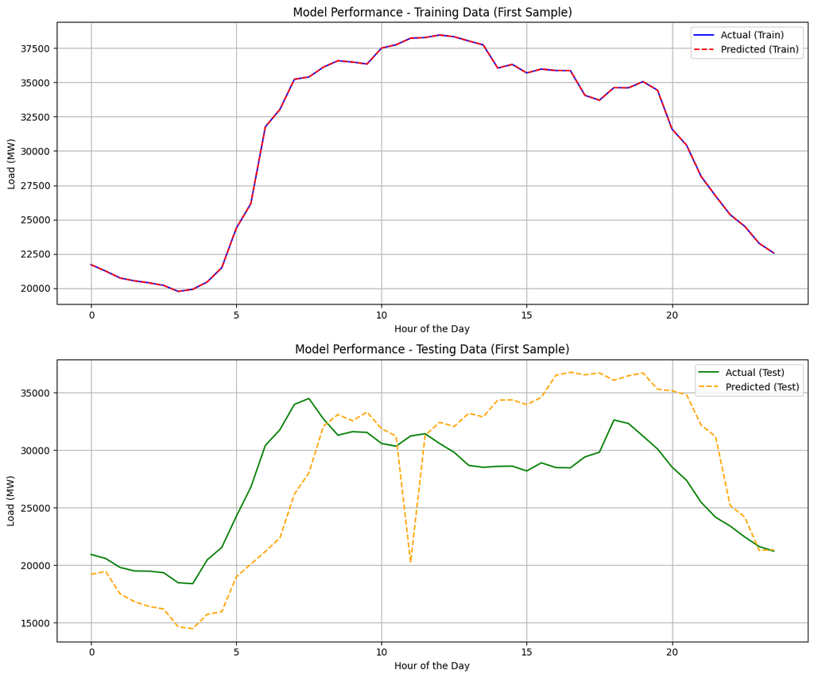

```
Training Data (First Sample):
Mean Absolute Error: 0.00
Root Mean Squared Error: 0.00

Testing Data (First Sample):
Mean Absolute Error: 4407.65
Root Mean Squared Error: 5192.63
```

```python
# Example code for dataset splitting, training, and testing. You may need to rewrite/reuse this routine for this or later parts.
# you should have this part working for the first run, to check your variables are properly named in Part 1.
import numpy as np
from sklearn.metrics import mean_squared_error, r2_score
from sklearn.model_selection import train_test_split
from sklearn.linear_model import LinearRegression


# Training and Testing dataset preparation. Splitting ratio between training and testing is set as 50% vs 50% as an example.
X_train, X_test, Y_train, Y_test = train_test_split(feature_dataset, label_dataset, test_size=0.5)

# Configuring the models to fit/train.
cwk_model_part2 = LinearRegression()

# Fitting the models with the training data.
cwk_model_part2.fit(X_train, Y_train)

# Making predictions with the fitted model
Y_train_output = cwk_model_part2.predict(X_train)

# Making predictions with the fitted model
Y_test_output= cwk_model_part2.predict(X_test)

###################################################
## Write your code for Task 2.1 here.
###################################################
# Write code to calculate the Mean Squared Error (MSE) performance for both the training part and the testing part, with the name of mse_train and mse_test, correspondingly. You will need to follow this naming convention for Part 3.

# value initialization - you might need to rewrite/remove this part if necessary
# mse_train = 1.0 # - you might need to rewrite/remove this part if necessary
# mse_test = 1.0 # - you might need to rewrite/remove this part if necessary

#


# Calculate MSE for training data
mse_train = mean_squared_error(Y_train, Y_train_output)

# Calculate MSE for testing data
mse_test = mean_squared_error(Y_test, Y_test_output)

# Print the results
print(f"Mean Squared Error (MSE) for training data: {mse_train:.2f}")
print(f"Mean Squared Error (MSE) for testing data: {mse_test:.2f}")

# Calculate and print Root Mean Squared Error (RMSE) for better interpretability
rmse_train = np.sqrt(mse_train)
rmse_test = np.sqrt(mse_test)
print(f"Root Mean Squared Error (RMSE) for training data: {rmse_train:.2f}")
print(f"Root Mean Squared Error (RMSE) for testing data: {rmse_test:.2f}")

# Calculate and print the R-squared score for both training and testing data
from sklearn.metrics import r2_score

r2_train = r2_score(Y_train, Y_train_output)
r2_test = r2_score(Y_test, Y_test_output)
print(f"R-squared score for training data: {r2_train:.4f}")
print(f"R-squared score for testing data: {r2_test:.4f}")
###################################################
# the following code should run with no problem after your implementation of Task 2.1
print("---------------------------------------------------------------------------")
print("MSE Performance for Part 2:")
print(f"Linear Regression MSE Train: {mse_train}")
print(f"Linear Regression MSE Test: {mse_test}")
print("---------------------------------------------------------------------------")

###################################################
## Write your code for Task 2.2 here.
###################################################
# Write code to visualize the model fitting performance. You should plot the first row of Y_train and Y_train_output, first row of Y_test_output and Y_test.

#
import matplotlib.pyplot as plt

# Create a time array for x-axis (48 half-hour periods)
time = np.arange(0, 24, 0.5)

# Create the plot
plt.figure(figsize=(12, 10))

# Plot training data
plt.subplot(2, 1, 1)
plt.plot(time, Y_train[0], label='Actual (Train)', color='blue')
plt.plot(time, Y_train_output[0], label='Predicted (Train)', color='red', linestyle='--')
plt.title('Model Performance - Training Data (First Sample)')
plt.xlabel('Hour of the Day')
plt.ylabel('Load (MW)')
plt.legend()
plt.grid(True)

# Plot testing data
plt.subplot(2, 1, 2)
plt.plot(time, Y_test[0], label='Actual (Test)', color='green')
plt.plot(time, Y_test_output[0], label='Predicted (Test)', color='orange', linestyle='--')
plt.title('Model Performance - Testing Data (First Sample)')
plt.xlabel('Hour of the Day')
plt.ylabel('Load (MW)')
plt.legend()
plt.grid(True)

# Adjust layout and display the plot
plt.tight_layout()
plt.show()

# Print some statistics for the plotted samples
print("Training Data (First Sample):")
print(f"Mean Absolute Error: {np.mean(np.abs(Y_train[0] - Y_train_output[0])):.2f}")
print(f"Root Mean Squared Error: {np.sqrt(np.mean((Y_train[0] - Y_train_output[0])**2)):.2f}")

print("\nTesting Data (First Sample):")
print(f"Mean Absolute Error: {np.mean(np.abs(Y_test[0] - Y_test_output[0])):.2f}")
print(f"Root Mean Squared Error: {np.sqrt(np.mean((Y_test[0] - Y_test_output[0])**2)):.2f}")
```

## Part 3: Model Explore

In this part, the expectation is: a) to choose your own model b) to prepare the data for the model training c) to configure the model and to train the model d) to report the performance

Note that: a) you can try as many models as you like, but you can only choose one as the final model to report. The final performance will be evaluated based on that model alone. b) if multiple models are left in this part without a clear indication of the final model selection, the LAST model will be used for marking purpose. c) your model will be evaluated following the convention of machine learning projects. An unknown dataset to you will be used to evaluate your model performance. Please don't ask for the dataset as it is kept away from you intentionally. d) your model should be able to load the example test dataset. It is mandatory to ensure your code is with the correct structure for the unknown dataset test, but DO NOT rely on its performance because the example test dataset is subset of your training dataset and NOT the unknown dataset for marking.

For this part you will be completing the code to evaluate the fitted model. You will be told what parts you need to write and blank spaces will be provided in the code below denoted by commnents (e.g. "Write your code for Task 1.1 here"). You may need to import any library functions you will use. For questions that have a text based answer you should write those in the space below the question (e.g. replace '[Write your answer here]')

**Task 3.1** Write your code to implement a different model (any model except LinearRegression model) and evaluate its performance. You should rewrite part of the following code.

**Task 3.2** Justify your choice for the implemented model. Write your answer below. *[write your answer here]* Example Answers: Reasonable regression model selections are ok, but expecting discussions.

I have chosen the RandomForestRegressor as my model for this task for several reasons:

1. Ability to capture non-linear relationships: Electricity load patterns can be complex and non-linear.Random Forests, being an ensemble of decision trees, can capture these intricate patterns better than simpler linear models.
2. Robustness to overfitting: As an ensemble method, Random Forests are less prone to overfitting compared to individual decision trees. This is crucial for generalization to unseen data in forecasting tasks.
3. Feature importance: Random Forests provide a measure of feature importance, which can offer insights into which time periods or features are most crucial for predicting the next day's load.

**Task 3.3** Compare and discuss the performance of your implemented models. Write your answer below. *[write your answer here]* Example Answers: Quantified evidence is expected to make the comparison; model/hyper parameters are expected to be used for the discussion.

**Task 3.4** What is overfitting? How to mitigate the overfitting in your implemented code? Write your answer below. *[write your answer here]* Example Answers: 1st class answers should also include code implementations, e.g., k-fold.

Overfitting occurs when a model learns the training data too well, including its noise and fluctuations, leading to poor generalization on unseen data.

1. Cross-validation: Implement k-fold cross-validation to get a more robust estimate of model performance.

from sklearn.model_selection import cross_val_score

scores = cross_val_score(cwk_model_part3, feature_dataset, label_dataset, cv=5, scoring='neg_mean_squared_error') print(f"Cross-validation MSE scores: {-scores}") print(f"Average MSE: {-scores.mean()}")

2. Hyperparameter tuning: Use RandomizedSearchCV to find optimal hyperparameters.

from sklearn.model_selection import RandomizedSearchCV

param_dist = { 'n_estimators': [50, 100, 200], 'max_depth': [10, 20, None], 'min_samples_split': [2, 5, 10], 'min_samples_leaf': [1, 2, 4] }

random_search = RandomizedSearchCV(RandomForestRegressor(random_state=42), param_distributions=param_dist, n_iter=20, cv=5, n_jobs=-1) random_search.fit(feature_dataset, label_dataset) print(f"Best parameters: {random_search.best_params_}") cwk_model_part3 = random_search.best_estimator_

3. Feature importance and selection: Identify and use only the most important features.

importances = cwk_model_part3.feature_importances_ indices = np.argsort(importances)[::-1] top_features = feature_dataset.columns[indices[:20]] # Top 20 features X_selected = feature_dataset[top_features]

```python
###################################################
## Write your code for Task 3.1 here.
###################################################
# Write your code to implement a different model (any model except LinearRegression model) and evaluate its performance. You should rewrite part of the following code.
# They are provided to give you hints about the model names to be expected in Part 4.
# The following code should be rewrite completely.

# X_train, X_test, Y_train, Y_test = train_test_split(feature_dataset, label_dataset, test_size=0.2)

# # Configuring the models to fit/train.
# cwk_model_part3 = LinearRegression()

# # Fitting the models with the training data.
# cwk_model_part3.fit(X_train, Y_train)

# # Making predictions with the fitted model
# Y_train_output = cwk_model_part3.predict(X_train)

# # Making predictions with the fitted model
# Y_test_output= cwk_model_part3.predict(X_test)

# #


# Importing the necessary libraries for RandomForestRegressor
from sklearn.ensemble import RandomForestRegressor
from sklearn.model_selection import train_test_split
from sklearn.metrics import mean_squared_error, r2_score

# Splitting the data into training and test sets
X_train, X_test, Y_train, Y_test = train_test_split(feature_dataset, label_dataset, test_size=0.2)

# Configuring the RandomForestRegressor model to fit/train.
cwk_model_part3 = RandomForestRegressor(n_estimators=100, random_state=42)

# Fitting the model with the training data
cwk_model_part3.fit(X_train, Y_train)

# Making predictions with the fitted model on training data
Y_train_output = cwk_model_part3.predict(X_train)

# Making predictions with the fitted model on testing data
Y_test_output = cwk_model_part3.predict(X_test)

# Evaluating the model's performance on the training data
train_mse = mean_squared_error(Y_train, Y_train_output)
train_r2 = r2_score(Y_train, Y_train_output)

# Evaluating the model's performance on the testing data
test_mse = mean_squared_error(Y_test, Y_test_output)
test_r2 = r2_score(Y_test, Y_test_output)

# Reporting the performance
print("RandomForestRegressor Performance:")
print(f"Training Mean Squared Error (MSE): {train_mse}")
print(f"Training R-squared: {train_r2}")
print(f"Testing Mean Squared Error (MSE): {test_mse}")
print(f"Testing R-squared: {test_r2}")
```

```
RandomForestRegressor Performance:
Training Mean Squared Error (MSE): 815075.5477739909
Training R-squared: 0.8946106786752474
Testing Mean Squared Error (MSE): 5221870.829367035
Testing R-squared: 0.13568717468701755
```

## Part 4: Model Evaluation

For this part you will be completing the code to evaluate the fitted model. You will be told what parts you need to write and blank spaces will be provided in the code below denoted by commnents (e.g. "Write your code for Task 1.1 here"). You may need to import any library functions you will use. For questions that have a text based answer you should write those in the space below the question (e.g. replace '[Write your answer here]')

**Task 4.1** Write code to use the data from "UKLoad2023_test.json" to evaluate your fitted model from Part 2. Note that the data provided in "UKLoad2023_test.json" is a dummy dataset, and during the marking process, another dataset with the same name and similar format will be use. The dataset for marking is NOT available to you, so please don't make requests to this dataset, but you should use the provided "UKLoad2023_test.json" to check if your code can run.

**Task 4.2** Given the overall aim is to make day-ahead load forecasting, please suggest an approach (other than the trial with different models) to better achieve this aim. Write your answer below. *[write your answer here]* Example Answers: The discussion on additional features or better cooking of the dataset/features, e.g., day of the week; seasonal changes; quality of the dataset.

To improve the day-ahead load forecasting model beyond simply trying different models, it is important to focus on enhancing the features and the quality of the dataset. Enhanced Feature Engineering

1. Incorporate temporal features: Add day of the week, month, and season as explicit features. This can help capture weekly and seasonal patterns in electricity consumption.
2. Create lag features: Include load values from previous days (e.g., yesterday's load, load from a week ago) to capture short-term and weekly trends.
3. Add rolling statistics: Compute moving averages and standard deviations of load over different time windows (e.g., 7-day, 30-day) to capture longer-term trends and variability.

**Task 4.3** Performance evaluation via overall_performance. You must make sure the following lines can run, or a 0 mark will be made for this task. overall_performance = performance_indicator_relative(mse_train, mse_test, mse_validation) print('overall_performance', overall_performance)

**Task 4.4** Performance evaluation via rmse_performance. You must make sure the following lines can run, or a 0 mark will be made for this task. rmse_performance = performance_indicator_rmse(mse_validation, label_dataset_validation) print('rmse_performance', rmse_performance)

```python
# To load the evaluation dataset
df_evaluation = pd.read_json('UKLoad2023_test.json')


###################################################
## Write your code for Task 4.1 here.
###################################################

# initialize the mse_validation - you might need to rewrite/remove this part if necessary
# mse_validation = 1.0 # - you might need to rewrite/remove this part if necessary

# # dataset initialization - you might need to rewrite/remove this part if necessary
# feature_dataset_validation = np.ones((10,10)) # - you might need to rewrite/remove this part if necessary
# label_dataset_validation   = np.ones((10,10)) # - you might need to rewrite/remove this part if necessary

###################################################
## Write your code for Task 4.1 here. Version 1
###################################################

import pandas as pd
import numpy as np
from sklearn.metrics import mean_squared_error, r2_score
from sklearn.impute import SimpleImputer

# Prepare the evaluation data
def prepare_data(df):
    # Group by date and create a 2D array of 48 half-hourly load values
    grouped = df.groupby('settlementDate')['quantity'].apply(list)
    return np.array([x for x in grouped if len(x) == 48])

# Prepare feature and label datasets for validation
feature_dataset_validation = prepare_data(df_evaluation)[:-1]  # All days except the last
label_dataset_validation = prepare_data(df_evaluation)[1:]    # All days except the first

# Ensure the datasets have the same shape
min_days = min(feature_dataset_validation.shape[0], label_dataset_validation.shape[0])
feature_dataset_validation = feature_dataset_validation[:min_days]
label_dataset_validation = label_dataset_validation[:min_days]

# Handle NaN values using SimpleImputer
imputer = SimpleImputer(strategy='mean')
feature_dataset_validation = imputer.fit_transform(feature_dataset_validation)
label_dataset_validation = imputer.fit_transform(label_dataset_validation)

# Make predictions using the RandomForest model from Part 3
Y_validation_output = cwk_model_part3.predict(feature_dataset_validation)

# Calculate MSE for validation
mse_validation = mean_squared_error(label_dataset_validation, Y_validation_output)

# Print results
print("\nValidation Results for RandomForest Model:")
print(f"Validation Mean Squared Error (MSE): {mse_validation}")

# Additional metrics for comprehensive evaluation
r2_validation = r2_score(label_dataset_validation, Y_validation_output)
rmse_validation = np.sqrt(mse_validation)

print(f"Validation R-squared: {r2_validation}")
print(f"Validation Root Mean Squared Error (RMSE): {rmse_validation}")

# Print shapes for verification
print("\nDataset Shapes:")
print(f"Feature dataset validation shape: {feature_dataset_validation.shape}")
print(f"Label dataset validation shape: {label_dataset_validation.shape}")
print(f"Predictions shape: {Y_validation_output.shape}")
```

```
Validation Results for RandomForest Model:
Validation Mean Squared Error (MSE): 8863932.14622754
Validation R-squared: -0.20755368185852494
Validation Root Mean Squared Error (RMSE): 2977.2356551384273

Dataset Shapes:
Feature dataset validation shape: (90, 48)
Label dataset validation shape: (90, 48)
Predictions shape: (90, 48)
```

```python
#################################################################################################################
## Performance Evaluation Part
# Please leave this part un-touched.
# They are provided for you to test if your code can be evaluated - the performance reported below is for
# your reference only and not the ones in marking. The dataset for marking is NOT available to you so don't ask for it.
overall_performance = performance_indicator_relative(mse_train, mse_test, mse_validation)
print('overall_performance', overall_performance)

rmse_performance = performance_indicator_rmse(mse_validation, label_dataset_validation)
print('rmse_performance', rmse_performance)
#################################################################################################################
```

```
overall_performance 2.1874122569836815e+27
rmse_performance 0.011410496536810966
```